# Kmiecik_Bear_Project

Magda Kmiecik

2023-04-26

### General Information

About the dataset: The dataset analyzed here is a subset of data from a previous study done by Srivastava et al. (cited below) which examines the expression profile of genes in kidneys from 12 American black bears (Ursus americanus) in Maine using RNA-Seq (6 Fall bears, 6 Spring bears). This was to aid in identifying genes for targeted therapies in humans who suffer from Chronic Kidney Disease (CKD). The purpose of this particular analysis was to detect if genes that were differentially expressed in bear kidneys after hibernation (spring) were related to cardiac pathways, particularly those affecting blood pressure. A total of 10 bear samples were used, 5 from fall and 5 from spring. Raw FastQ files were downloaded from NCBI’s Sequence Read Archive under the accession number SRP075217 (specific sample names in supplement labeled bear.txt). These files were used as input for HISAT2 alignment, from which the resulting .bam files were run through HTSeq to create counts files. These counts files are the starting input for this document and the resulting counts matrix will be utilized to create visualizations.

Please read this through first, and run different sections separately. Editing of files externally is required.

Citation: Srivastava, A., Kumar Sarsani, V., Fiddes, I., Sheehan, S. M., Seger, R. L., Barter, M. E., Neptune-Bear, S., Lindqvist, C., & Korstanje, R. (2019). Genome assembly and gene expression in the American black bear provides new insights into the renal response to hibernation. DNA research : an international journal for rapid publication of reports on genes and genomes, 26(1), 37–44. https://doi.org/10.1093/dnares/dsy036

Supplemental Files in Folder: Kmiecik_Bear_Supplemental

Note: some packages require BiocManager to be installed.

### Load Libraries

```r
library(knitr)
library(DESeq2)
library(RColorBrewer)
library(pheatmap)
library(ggplot2)
library(tidyverse)
library(EnhancedVolcano)
library(biomaRt)
library(dplyr)
library(tidyr)
library(cowplot)
library(ggnewscale)
library(ggupset)
library(clusterProfiler)
library(org.Mm.eg.db)
library(DOSE)
library(pathview)
library(enrichplot)
library(limma)
library(ggplotify)
library(hypeR)
```

## Creating DESeq Objects

### Make Annotation

```r
# read in annotation file
sampleTable <- read.csv("bear_anno.csv", header = T)
head(sampleTable)
```

```
##       sample              filename    sex season               identity
## 1 SRR7811754 SRR7811754.ENSG.count female   fall   JAX118_Fall_RNA_Bear
## 2 SRR7811767 SRR7811767.ENSG.count female   fall   JAX134_Fall_RNA_Bear
## 3 SRR7811766 SRR7811766.ENSG.count female   fall  JAX_160_Fall_RNA_Bear
## 4 SRR7811762 SRR7811762.ENSG.count   male   fall   JAX141_Fall_RNA_Bear
## 5 SRR7811764 SRR7811764.ENSG.count   male   fall   JAX165_Fall_RNA_Bear
## 6 SRR7811759 SRR7811759.ENSG.count female spring JAX106_Spring_RNA_Bear
##   replicate
## 1         1
## 2         2
## 3         3
## 4         4
## 5         5
## 6         1
```

```r
# convert file to data frame
sampleTable <- data.frame(sampleTable)
head(sampleTable)
```

```
##       sample              filename    sex season               identity
## 1 SRR7811754 SRR7811754.ENSG.count female   fall   JAX118_Fall_RNA_Bear
## 2 SRR7811767 SRR7811767.ENSG.count female   fall   JAX134_Fall_RNA_Bear
## 3 SRR7811766 SRR7811766.ENSG.count female   fall  JAX_160_Fall_RNA_Bear
## 4 SRR7811762 SRR7811762.ENSG.count   male   fall   JAX141_Fall_RNA_Bear
## 5 SRR7811764 SRR7811764.ENSG.count   male   fall   JAX165_Fall_RNA_Bear
## 6 SRR7811759 SRR7811759.ENSG.count female spring JAX106_Spring_RNA_Bear
##   replicate
## 1         1
## 2         2
## 3         3
## 4         4
## 5         5
## 6         1
```

```r
str(sampleTable)
```

```
## 'data.frame':    10 obs. of  6 variables:
##  $ sample   : chr  "SRR7811754" "SRR7811767" "SRR7811766" "SRR7811762" ...
##  $ filename : chr  "SRR7811754.ENSG.count" "SRR7811767.ENSG.count" "SRR7811766.ENSG.count" "SRR7811762.ENSG.count" ...
##  $ sex      : chr  "female" "female" "female" "male" ...
##  $ season   : chr  "fall" "fall" "fall" "fall" ...
##  $ identity : chr  "JAX118_Fall_RNA_Bear" "JAX134_Fall_RNA_Bear" "JAX_160_Fall_RNA_Bear" "JAX141_Fall_RNA_Bear" ...
##  $ replicate: int  1 2 3 4 5 1 2 3 4 5
```

```r
# specify 'season' and 'sex' as factors so they can be stored as levels
season <- factor(sampleTable$season)
sex <- factor(sampleTable$sex)
```

### Create DESeq Data Set

```r
# make dds object out of count matrix
dds <- DESeqDataSetFromHTSeqCount(sampleTable = sampleTable,
                                  directory = ".",
                                  design = ~ sex + season)

dds
```

```
## class: DESeqDataSet
## dim: 24647 10
## metadata(1): version
## assays(1): counts
## rownames(24647): ENSUAMG00000000001 ENSUAMG00000000002 ...
##   ENSUAMG00000028450 ENSUAMG00000028451
## rowData names(0):
## colnames(10): SRR7811754 SRR7811767 ... SRR7811757 SRR7811750
## colData names(4): sex season identity replicate
```

### Prefilter Data

```r
# filter out rows with less than 10 reads total
keep <- rowSums(counts(dds)) >= 10
dds <- dds[keep,]

dds
```

```
## class: DESeqDataSet
## dim: 18442 10
## metadata(1): version
## assays(1): counts
## rownames(18442): ENSUAMG00000000001 ENSUAMG00000000002 ...
##   ENSUAMG00000028448 ENSUAMG00000028450
## rowData names(0):
## colnames(10): SRR7811754 SRR7811767 ... SRR7811757 SRR7811750
## colData names(4): sex season identity replicate
```

### Relevel Data

```r
# relevel data to specify reference level
dds$season <- relevel(dds$season, ref = "fall")

dds
```

```
## class: DESeqDataSet
## dim: 18442 10
## metadata(1): version
## assays(1): counts
## rownames(18442): ENSUAMG00000000001 ENSUAMG00000000002 ...
##   ENSUAMG00000028448 ENSUAMG00000028450
## rowData names(0):
## colnames(10): SRR7811754 SRR7811767 ... SRR7811757 SRR7811750
## colData names(4): sex season identity replicate
```

### Differential Expression Analysis

```r
# generate results table--------------------------------------------------------
dds <- DESeq(dds)

resdata <- results(dds, contrast=c('season', 'spring', 'fall'))
head(resdata)
```

```
## log2 fold change (MLE): season spring vs fall
## Wald test p-value: season spring vs fall
## DataFrame with 6 rows and 6 columns
##                     baseMean log2FoldChange     lfcSE      stat     pvalue
##                    <numeric>      <numeric> <numeric> <numeric>  <numeric>
## ENSUAMG00000000001 975.79943     -0.1175525  0.118821 -0.989324 0.32250465
## ENSUAMG00000000002 413.65877     -0.3175965  0.115158 -2.757929 0.00581688
## ENSUAMG00000000003   9.97792      0.1805817  0.603795  0.299078 0.76488066
## ENSUAMG00000000004 453.12851      0.0378547  0.105520  0.358743 0.71978760
## ENSUAMG00000000005 257.06768     -0.1494567  0.124226 -1.203107 0.22893479
## ENSUAMG00000000006 206.70608     -0.0389975  0.190519 -0.204691 0.83781334
##                         padj
##                    <numeric>
## ENSUAMG00000000001  0.818765
## ENSUAMG00000000002  0.186141
## ENSUAMG00000000003  0.968891
## ENSUAMG00000000004  0.958208
## ENSUAMG00000000005  0.757165
## ENSUAMG00000000006  0.982058
```

```r
# order our results table by the smallest *padj* value
result <- resdata[order(resdata$padj), ]
head(result)
```

```
## log2 fold change (MLE): season spring vs fall
## Wald test p-value: season spring vs fall
## DataFrame with 6 rows and 6 columns
##                     baseMean log2FoldChange     lfcSE      stat      pvalue
##                    <numeric>      <numeric> <numeric> <numeric>   <numeric>
## ENSUAMG00000013871 1418.9993       2.112438  0.254439   8.30234 1.02080e-16
## ENSUAMG00000025404  750.3986       0.950526  0.120870   7.86405 3.71921e-15
## ENSUAMG00000016889  220.7612       2.585296  0.389799   6.63239 3.30296e-11
## ENSUAMG00000004830 1807.5093       1.237404  0.196620   6.29338 3.10623e-10
## ENSUAMG00000011450  188.9931      -1.401083  0.223633  -6.26509 3.72606e-10
## ENSUAMG00000016642   20.0035       3.431601  0.561403   6.11254 9.80572e-10
##                           padj
##                      <numeric>
## ENSUAMG00000013871 1.62358e-12
## ENSUAMG00000025404 2.95770e-11
## ENSUAMG00000016889 1.75112e-07
## ENSUAMG00000004830 1.18526e-06
## ENSUAMG00000011450 1.18526e-06
## ENSUAMG00000016642 2.59933e-06
```

```r
# identify number of DEG based on padj < 0.05
table(result$padj<0.05)
```

```
##
## FALSE  TRUE
## 15739   166
```

DEGs based on p-adjusted value can be merged with the dds object in the prefiltering step to return an unfiltered matrix. This matrix is important for further analysis!

```r
resdata <- merge(as.data.frame(result), as.data.frame(counts(dds, normalized=TRUE)), by="row.names", sort=FALSE)
names(resdata)[1] <- "Gene_id"
head(resdata)
```

```
##              Gene_id  baseMean log2FoldChange     lfcSE      stat       pvalue
## 1 ENSUAMG00000013871 1418.9993      2.1124384 0.2544389  8.302341 1.020800e-16
## 2 ENSUAMG00000025404  750.3986      0.9505259 0.1208698  7.864046 3.719209e-15
## 3 ENSUAMG00000016889  220.7612      2.5852960 0.3897986  6.632389 3.302964e-11
## 4 ENSUAMG00000004830 1807.5093      1.2374040 0.1966199  6.293382 3.106228e-10
## 5 ENSUAMG00000011450  188.9931     -1.4010826 0.2236332 -6.265092 3.726059e-10
## 6 ENSUAMG00000016642   20.0035      3.4316008 0.5614033  6.112541 9.805715e-10
##           padj  SRR7811754 SRR7811767  SRR7811766 SRR7811762 SRR7811764
## 1 1.623582e-12  858.003269 329.633995  632.099887  385.40127 483.835954
## 2 2.957701e-11  574.166512 419.447315  549.457852  473.08006 543.333183
## 3 1.751121e-07   64.002406  20.064678   93.809877   45.28465  83.071602
## 4 1.185259e-06 1216.973285 955.460854 1260.849421 1157.16731 762.238081
## 5 1.185259e-06  166.035227 358.297820  217.772929  321.81006 301.976500
## 6 2.599332e-06    4.637856   5.732765    2.233569    2.89051   1.122589
##   SRR7811759 SRR7811758 SRR7811765 SRR7811757 SRR7811750
## 1 2818.29622  1761.1367 2029.35569 1871.78676 3020.44305
## 2 1004.18904   866.0177 1065.29564 1053.59299  955.40539
## 3  347.49866   298.0385  740.22722  317.32230  198.29169
## 4 2008.37808  2125.4060 2557.82406 3739.42552 2291.37059
## 5   74.78974   108.3776   78.94519  132.73613  129.19004
## 6   45.60350    62.2168   33.43561   32.14703   10.01473
```

```r
#write results
write.csv(resdata, file="FallvsSpring_unfiltered_matrix.csv")
```

The below chunks are to get a list of differentially expressed genes (DEGs) based on the definition of a DEG which in the case of the paper was padj < 0.05. Here I will make two files, one accounting for both lof2FC > 1 & padj < 0.05 as well as just padj < 0.05.

```r
#Get DEG up/down lists for lof2FC and padj
resdata <- as.data.frame(result) %>% dplyr::filter(abs(log2FoldChange) > 1 & padj < 0.05) %>% tibble::rownames_to_column("Gene_id")

#write results
write.csv(resdata, "FallvsSpring_log2fc1_fdr05_DEGlist.csv", row.names = TRUE)

head(resdata)
```

```
##              Gene_id  baseMean log2FoldChange     lfcSE      stat       pvalue
## 1 ENSUAMG00000013871 1418.9993       2.112438 0.2544389  8.302341 1.020800e-16
## 2 ENSUAMG00000016889  220.7612       2.585296 0.3897986  6.632389 3.302964e-11
## 3 ENSUAMG00000004830 1807.5093       1.237404 0.1966199  6.293382 3.106228e-10
## 4 ENSUAMG00000011450  188.9931      -1.401083 0.2236332 -6.265092 3.726059e-10
## 5 ENSUAMG00000016642   20.0035       3.431601 0.5614033  6.112541 9.805715e-10
## 6 ENSUAMG00000005847  232.9705      -1.151563 0.1921459 -5.993172 2.057872e-09
##           padj
## 1 1.623582e-12
## 2 1.751121e-07
## 3 1.185259e-06
## 4 1.185259e-06
## 5 2.599332e-06
## 6 4.091306e-06
```

```r
#Get DEG up/down lists for just padj
resdata2 <- as.data.frame(result) %>% dplyr::filter(padj < 0.05) %>% tibble::rownames_to_column("Gene_id")

#write results
write.csv(resdata2, "FallvsSpring_padj05_DEGlist.csv", row.names = TRUE)

head(resdata2)
```

```
##              Gene_id  baseMean log2FoldChange     lfcSE      stat       pvalue
## 1 ENSUAMG00000013871 1418.9993      2.1124384 0.2544389  8.302341 1.020800e-16
## 2 ENSUAMG00000025404  750.3986      0.9505259 0.1208698  7.864046 3.719209e-15
## 3 ENSUAMG00000016889  220.7612      2.5852960 0.3897986  6.632389 3.302964e-11
## 4 ENSUAMG00000004830 1807.5093      1.2374040 0.1966199  6.293382 3.106228e-10
## 5 ENSUAMG00000011450  188.9931     -1.4010826 0.2236332 -6.265092 3.726059e-10
## 6 ENSUAMG00000016642   20.0035      3.4316008 0.5614033  6.112541 9.805715e-10
##           padj
## 1 1.623582e-12
## 2 2.957701e-11
## 3 1.751121e-07
## 4 1.185259e-06
## 5 1.185259e-06
## 6 2.599332e-06
```

Determining number of upregulated and downregulated genes

```r
upreg <-
  resdata2 %>%
  filter(log2FoldChange > 0 & padj < 0.05)
nrow(upreg)
```

```
## [1] 79
```

```r
downreg <-
  resdata2 %>%
  filter(log2FoldChange < 0 & padj < 0.05)
nrow(downreg)
```

```
## [1] 87
```

## Quality Visualizations

### Principal Component Analysis (PCA)

PCA plots are an important part in visualizing the variation in your samples. Based on season and sex we would expect some sort of clustering to indicate that the samples are representative of differences between each other.

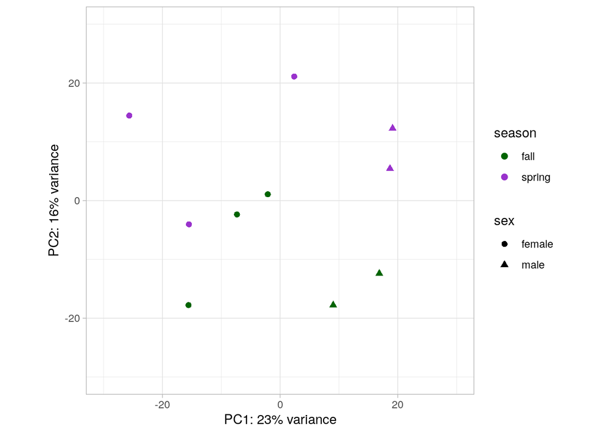

```r
# perform variance stabilizing transformation
vstcounts <- vst(dds, blind = FALSE)

# make PCA plot using ggplot
pcaData <- plotPCA(vstcounts, intgroup="season", "sex", returnData=TRUE)
percentVar <- round(100 * attr(pcaData, "percentVar"))
ggplot(pcaData, aes(PC1, PC2, color=season, shape=sex)) +
  scale_color_manual(values = c('darkgreen', 'darkorchid')) +
  geom_point(size=2) +
  ylim(-30,30) +
  xlim(-30,30) +
  xlab(paste0("PC1: ",percentVar[1],"% variance")) +
  ylab(paste0("PC2: ",percentVar[2],"% variance")) +
  theme_light() +
  coord_fixed()
```

However, a batch correction is needed since sex could be affecting the comparison between seasons.

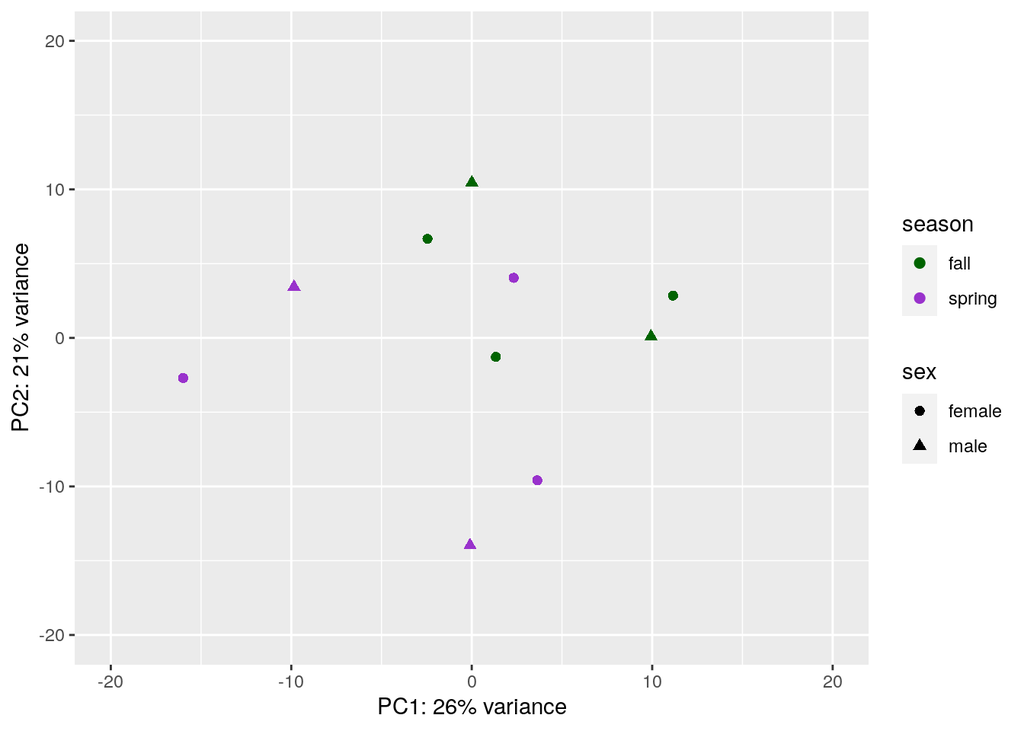

```r
assay(vstcounts) <- limma::removeBatchEffect(assay(vstcounts), vstcounts$sex)

pcaData <- plotPCA(vstcounts, intgroup=c("season", "sex"), returnData=TRUE)
percentVar <- round(100 * attr(pcaData, "percentVar"))
ggplot(pcaData, aes(PC1, PC2, color=season, shape=sex)) +
  scale_color_manual(values = c('darkgreen', 'darkorchid')) +
geom_point(size=2) +
xlim(-20, 20) +
ylim(-20, 20) +
xlab(paste0("PC1: ",percentVar[1],"% variance")) +
ylab(paste0("PC2: ",percentVar[2],"% variance"))
```

### Correlation Heatmap

A correlation heatmap represents the relationship between the variable season in a color-coordinated matrix.

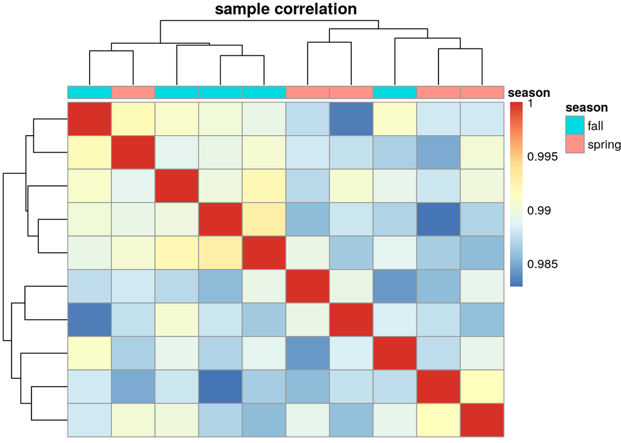

```r
vst_mat <- assay(vstcounts)
vst_cor <- cor(vst_mat)
annotation_heatmap <- data.frame(row.names=colnames(vst_mat), season)

pheatmap(vst_cor,
         annotation_col = annotation_heatmap,  main = "sample correlation", show_rownames = F, show_colnames = F)
```

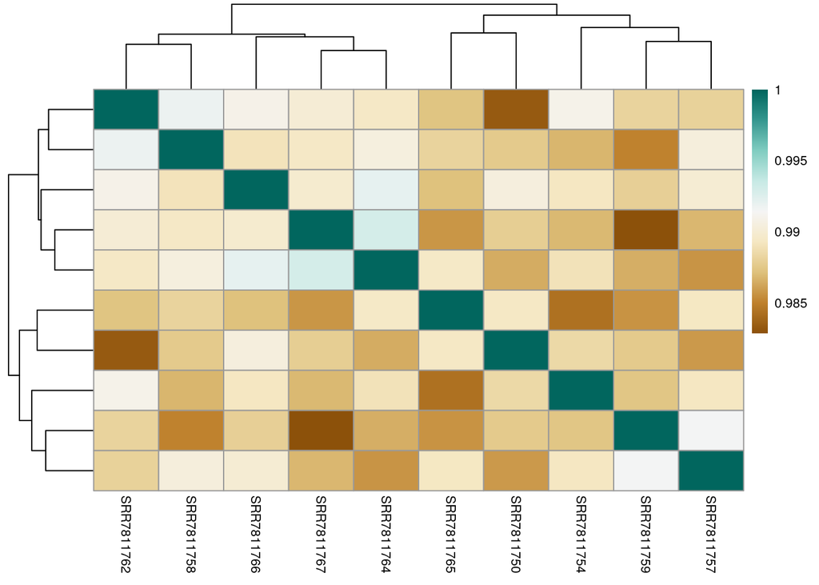

```r
# change aesthetics for readability
pheatmap(vst_cor, clustering_distance_rows = "euclidean",
         fontsize = 8,  cellwidth = 40, show_rownames = F, color =
           colorRampPalette(brewer.pal(9,"BrBG"))(400))
```

## Volcano plots

Volcano plots are a form of scatterplot that depict changes between a variable in the dataset. Here it is representing DEGs in spring bears compared to fall bears.

### Prepping the data

```r
resdata <- read.csv("FallvsSpring_unfiltered_matrix.csv", header = T)
resdata <- resdata[, c(2:14)]
head(resdata)
```

```
##              Gene_id  baseMean log2FoldChange     lfcSE      stat       pvalue
## 1 ENSUAMG00000013871 1418.9993      2.1124384 0.2544389  8.302341 1.020800e-16
## 2 ENSUAMG00000025404  750.3986      0.9505259 0.1208698  7.864046 3.719209e-15
## 3 ENSUAMG00000016889  220.7612      2.5852960 0.3897986  6.632389 3.302964e-11
## 4 ENSUAMG00000004830 1807.5093      1.2374040 0.1966199  6.293382 3.106228e-10
## 5 ENSUAMG00000011450  188.9931     -1.4010826 0.2236332 -6.265092 3.726059e-10
## 6 ENSUAMG00000016642   20.0035      3.4316008 0.5614033  6.112541 9.805715e-10
##           padj  SRR7811754 SRR7811767  SRR7811766 SRR7811762 SRR7811764
## 1 1.623582e-12  858.003269 329.633995  632.099887  385.40127 483.835954
## 2 2.957701e-11  574.166512 419.447315  549.457852  473.08006 543.333183
## 3 1.751121e-07   64.002406  20.064678   93.809877   45.28465  83.071602
## 4 1.185259e-06 1216.973285 955.460854 1260.849421 1157.16731 762.238081
## 5 1.185259e-06  166.035227 358.297820  217.772929  321.81006 301.976500
## 6 2.599332e-06    4.637856   5.732765    2.233569    2.89051   1.122589
##   SRR7811759
## 1 2818.29622
## 2 1004.18904
## 3  347.49866
## 4 2008.37808
## 5   74.78974
## 6   45.60350
```

```r
str(resdata)
```

```
## 'data.frame':    18442 obs. of  13 variables:
##  $ Gene_id       : chr  "ENSUAMG00000013871" "ENSUAMG00000025404" "ENSUAMG00000016889" "ENSUAMG00000004830" ...
##  $ baseMean      : num  1419 750 221 1808 189 ...
##  $ log2FoldChange: num  2.112 0.951 2.585 1.237 -1.401 ...
##  $ lfcSE         : num  0.254 0.121 0.39 0.197 0.224 ...
##  $ stat          : num  8.3 7.86 6.63 6.29 -6.27 ...
##  $ pvalue        : num  1.02e-16 3.72e-15 3.30e-11 3.11e-10 3.73e-10 ...
##  $ padj          : num  1.62e-12 2.96e-11 1.75e-07 1.19e-06 1.19e-06 ...
##  $ SRR7811754    : num  858 574 64 1217 166 ...
##  $ SRR7811767    : num  329.6 419.4 20.1 955.5 358.3 ...
##  $ SRR7811766    : num  632.1 549.5 93.8 1260.8 217.8 ...
##  $ SRR7811762    : num  385.4 473.1 45.3 1157.2 321.8 ...
##  $ SRR7811764    : num  483.8 543.3 83.1 762.2 302 ...
##  $ SRR7811759    : num  2818.3 1004.2 347.5 2008.4 74.8 ...
```

A column can be added to the dataset that shows whether the gene is differentially expressed based on padj < 0.05. This creates a logical vector where `TRUE` represents genes with padj < 0.05 and `FALSE` means it does not meet this criteria (padj > 0.05).

```r
threshold_padj <- resdata$padj < 0.05
length(which(threshold_padj)) ## Determine the number of TRUE values
```

```
## [1] 166
```

We can add the logical vector to the dataset

```r
resdata$threshold <- threshold_padj ## Add vector as a column (threshold) to the resdata
str(resdata)
```

```
## 'data.frame':    18442 obs. of  14 variables:
##  $ Gene_id       : chr  "ENSUAMG00000013871" "ENSUAMG00000025404" "ENSUAMG00000016889" "ENSUAMG00000004830" ...
##  $ baseMean      : num  1419 750 221 1808 189 ...
##  $ log2FoldChange: num  2.112 0.951 2.585 1.237 -1.401 ...
##  $ lfcSE         : num  0.254 0.121 0.39 0.197 0.224 ...
##  $ stat          : num  8.3 7.86 6.63 6.29 -6.27 ...
##  $ pvalue        : num  1.02e-16 3.72e-15 3.30e-11 3.11e-10 3.73e-10 ...
##  $ padj          : num  1.62e-12 2.96e-11 1.75e-07 1.19e-06 1.19e-06 ...
##  $ SRR7811754    : num  858 574 64 1217 166 ...
##  $ SRR7811767    : num  329.6 419.4 20.1 955.5 358.3 ...
##  $ SRR7811766    : num  632.1 549.5 93.8 1260.8 217.8 ...
##  $ SRR7811762    : num  385.4 473.1 45.3 1157.2 321.8 ...
##  $ SRR7811764    : num  483.8 543.3 83.1 762.2 302 ...
##  $ SRR7811759    : num  2818.3 1004.2 347.5 2008.4 74.8 ...
##  $ threshold     : logi  TRUE TRUE TRUE TRUE TRUE TRUE ...
```

```r
head(resdata)
```

```
##              Gene_id  baseMean log2FoldChange     lfcSE      stat       pvalue
## 1 ENSUAMG00000013871 1418.9993      2.1124384 0.2544389  8.302341 1.020800e-16
## 2 ENSUAMG00000025404  750.3986      0.9505259 0.1208698  7.864046 3.719209e-15
## 3 ENSUAMG00000016889  220.7612      2.5852960 0.3897986  6.632389 3.302964e-11
## 4 ENSUAMG00000004830 1807.5093      1.2374040 0.1966199  6.293382 3.106228e-10
## 5 ENSUAMG00000011450  188.9931     -1.4010826 0.2236332 -6.265092 3.726059e-10
## 6 ENSUAMG00000016642   20.0035      3.4316008 0.5614033  6.112541 9.805715e-10
##           padj  SRR7811754 SRR7811767  SRR7811766 SRR7811762 SRR7811764
## 1 1.623582e-12  858.003269 329.633995  632.099887  385.40127 483.835954
## 2 2.957701e-11  574.166512 419.447315  549.457852  473.08006 543.333183
## 3 1.751121e-07   64.002406  20.064678   93.809877   45.28465  83.071602
## 4 1.185259e-06 1216.973285 955.460854 1260.849421 1157.16731 762.238081
## 5 1.185259e-06  166.035227 358.297820  217.772929  321.81006 301.976500
## 6 2.599332e-06    4.637856   5.732765    2.233569    2.89051   1.122589
##   SRR7811759 threshold
## 1 2818.29622      TRUE
## 2 1004.18904      TRUE
## 3  347.49866      TRUE
## 4 2008.37808      TRUE
## 5   74.78974      TRUE
## 6   45.60350      TRUE
```

Create a volcano plot using ggplot() function

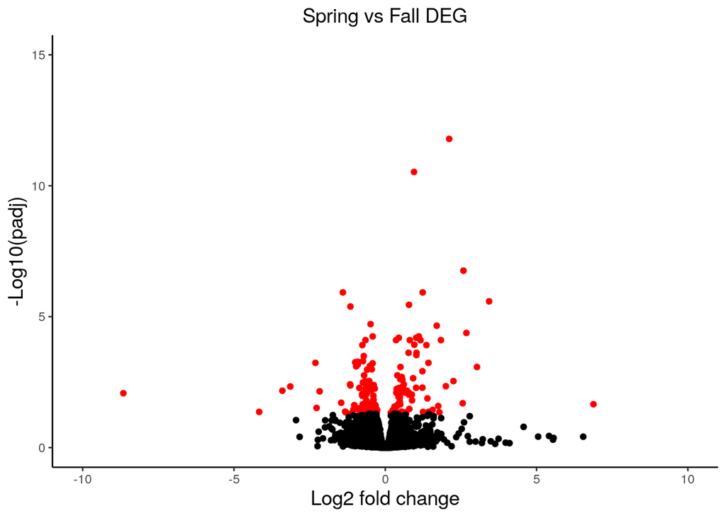

```r
ggplot(resdata) +
        geom_point(aes(x=log2FoldChange,
                       y=-log10(padj), colour=threshold)) +
  theme_classic() +
        ggtitle("Spring vs Fall DEG") +
        xlab("Log2 fold change") +
        ylab("-Log10(padj)") +
        theme(legend.position = "none",
              plot.title = element_text(size = rel(1.25), hjust = 0.5),
              axis.title = element_text(size = rel(1.25))) +
  scale_color_manual(values = c("black", "red")) +
  scale_x_continuous(limits = c(-10, 10)) +
  coord_cartesian(ylim=c(0, 15), clip = "off")
```

```r
#ggsave("SpringvsFall_DEG-volano.png")
```

## Volcano plot with Enhanced Volcano

Enhanced volcano takes volcano plots to the next level by being able to label genes of interest within the plot.

### Data input

```r
resdata <- read.csv("FallvsSpring_unfiltered_matrix.csv", header = T)
resdata <- resdata[, c(2:18)]
head(resdata)
```

```
##              Gene_id  baseMean log2FoldChange     lfcSE      stat       pvalue
## 1 ENSUAMG00000013871 1418.9993      2.1124384 0.2544389  8.302341 1.020800e-16
## 2 ENSUAMG00000025404  750.3986      0.9505259 0.1208698  7.864046 3.719209e-15
## 3 ENSUAMG00000016889  220.7612      2.5852960 0.3897986  6.632389 3.302964e-11
## 4 ENSUAMG00000004830 1807.5093      1.2374040 0.1966199  6.293382 3.106228e-10
## 5 ENSUAMG00000011450  188.9931     -1.4010826 0.2236332 -6.265092 3.726059e-10
## 6 ENSUAMG00000016642   20.0035      3.4316008 0.5614033  6.112541 9.805715e-10
##           padj  SRR7811754 SRR7811767  SRR7811766 SRR7811762 SRR7811764
## 1 1.623582e-12  858.003269 329.633995  632.099887  385.40127 483.835954
## 2 2.957701e-11  574.166512 419.447315  549.457852  473.08006 543.333183
## 3 1.751121e-07   64.002406  20.064678   93.809877   45.28465  83.071602
## 4 1.185259e-06 1216.973285 955.460854 1260.849421 1157.16731 762.238081
## 5 1.185259e-06  166.035227 358.297820  217.772929  321.81006 301.976500
## 6 2.599332e-06    4.637856   5.732765    2.233569    2.89051   1.122589
##   SRR7811759 SRR7811758 SRR7811765 SRR7811757 SRR7811750
## 1 2818.29622  1761.1367 2029.35569 1871.78676 3020.44305
## 2 1004.18904   866.0177 1065.29564 1053.59299  955.40539
## 3  347.49866   298.0385  740.22722  317.32230  198.29169
## 4 2008.37808  2125.4060 2557.82406 3739.42552 2291.37059
## 5   74.78974   108.3776   78.94519  132.73613  129.19004
## 6   45.60350    62.2168   33.43561   32.14703   10.01473
```

### BioMart id conversion

BioMart will be used to gather gene annotation data. Using `listEnsembl()`, `genes` was selected as the database

```r
listEnsembl()
```

```
##         biomart                version
## 1         genes      Ensembl Genes 109
## 2 mouse_strains      Mouse strains 109
## 3          snps  Ensembl Variation 109
## 4    regulation Ensembl Regulation 109
```

`useEnsembl()` was used to identify dataset and mirror (based on location, `useast` was used).

```r
ensembl <- useEnsembl(biomart = "genes", mirror="useast")
```

Species specific datasets canbe found by running `View(listDatasets(ensembl))`. American black bear was found to be `uamericanus_gene_ensembl`.

```r
ensembl <- useEnsembl(biomart = "genes", dataset = "uamericanus_gene_ensembl")
```

Given the matrix, ensembl gene ids were used as the identifier for bear. The outputs desired are external gene names. Run these codes to figure out filters, identifier already in the matrix, and attributes, identifiers that want to be added to the matrix.

```r
#View(listFilters(ensembl)) #ensembl_gene_id_version
#View(listAttributes(ensembl)) #external_gene_name
```

Using desired filter and attributes, gene identifiers can be produced.

```r
biomart.output <- getBM(mart = ensembl, values = resdata$Gene_id,
                      filters = "ensembl_gene_id",
                      attributes = c("external_gene_name",
                                     "ensembl_gene_id"))

head(biomart.output)
```

```
##   external_gene_name    ensembl_gene_id
## 1           TMEM161A ENSUAMG00000000002
## 2               MAU2 ENSUAMG00000000016
## 3                    ENSUAMG00000000031
## 4             GIGYF1 ENSUAMG00000000048
## 5                    ENSUAMG00000000049
## 6             SNORA8 ENSUAMG00000000062
```

Look at structure of resdata object

```r
str(resdata)
```

```
## 'data.frame':    18442 obs. of  17 variables:
##  $ Gene_id       : chr  "ENSUAMG00000013871" "ENSUAMG00000025404" "ENSUAMG00000016889" "ENSUAMG00000004830" ...
##  $ baseMean      : num  1419 750 221 1808 189 ...
##  $ log2FoldChange: num  2.112 0.951 2.585 1.237 -1.401 ...
##  $ lfcSE         : num  0.254 0.121 0.39 0.197 0.224 ...
##  $ stat          : num  8.3 7.86 6.63 6.29 -6.27 ...
##  $ pvalue        : num  1.02e-16 3.72e-15 3.30e-11 3.11e-10 3.73e-10 ...
##  $ padj          : num  1.62e-12 2.96e-11 1.75e-07 1.19e-06 1.19e-06 ...
##  $ SRR7811754    : num  858 574 64 1217 166 ...
##  $ SRR7811767    : num  329.6 419.4 20.1 955.5 358.3 ...
##  $ SRR7811766    : num  632.1 549.5 93.8 1260.8 217.8 ...
##  $ SRR7811762    : num  385.4 473.1 45.3 1157.2 321.8 ...
##  $ SRR7811764    : num  483.8 543.3 83.1 762.2 302 ...
##  $ SRR7811759    : num  2818.3 1004.2 347.5 2008.4 74.8 ...
##  $ SRR7811758    : num  1761 866 298 2125 108 ...
##  $ SRR7811765    : num  2029.4 1065.3 740.2 2557.8 78.9 ...
##  $ SRR7811757    : num  1872 1054 317 3739 133 ...
##  $ SRR7811750    : num  3020 955 198 2291 129 ...
```

Output gene names want to be added to this data frame

```r
resdata_gene <- dplyr::left_join(resdata, biomart.output,
                        by=c('Gene_id'='ensembl_gene_id'))
resdata_gene <- resdata_gene[, c(18, 1:17)]
str(resdata_gene)
```

```
## 'data.frame':    18442 obs. of  18 variables:
##  $ external_gene_name: chr  "CISH" "SOCS2" "SLCO1C1" "" ...
##  $ Gene_id           : chr  "ENSUAMG00000013871" "ENSUAMG00000025404" "ENSUAMG00000016889" "ENSUAMG00000004830" ...
##  $ baseMean          : num  1419 750 221 1808 189 ...
##  $ log2FoldChange    : num  2.112 0.951 2.585 1.237 -1.401 ...
##  $ lfcSE             : num  0.254 0.121 0.39 0.197 0.224 ...
##  $ stat              : num  8.3 7.86 6.63 6.29 -6.27 ...
##  $ pvalue            : num  1.02e-16 3.72e-15 3.30e-11 3.11e-10 3.73e-10 ...
##  $ padj              : num  1.62e-12 2.96e-11 1.75e-07 1.19e-06 1.19e-06 ...
##  $ SRR7811754        : num  858 574 64 1217 166 ...
##  $ SRR7811767        : num  329.6 419.4 20.1 955.5 358.3 ...
##  $ SRR7811766        : num  632.1 549.5 93.8 1260.8 217.8 ...
##  $ SRR7811762        : num  385.4 473.1 45.3 1157.2 321.8 ...
##  $ SRR7811764        : num  483.8 543.3 83.1 762.2 302 ...
##  $ SRR7811759        : num  2818.3 1004.2 347.5 2008.4 74.8 ...
##  $ SRR7811758        : num  1761 866 298 2125 108 ...
##  $ SRR7811765        : num  2029.4 1065.3 740.2 2557.8 78.9 ...
##  $ SRR7811757        : num  1872 1054 317 3739 133 ...
##  $ SRR7811750        : num  3020 955 198 2291 129 ...
```

To make the Enhanced volcano plot, a data frame was created selecting only relevant DEGs using padj < 0.05 as the parameter as specified in the original paper.

```r
resdata_sig <- as.data.frame(resdata_gene) %>% dplyr::filter(padj < 0.05)
head(resdata_sig)
```

```
##   external_gene_name            Gene_id  baseMean log2FoldChange     lfcSE
## 1               CISH ENSUAMG00000013871 1418.9993      2.1124384 0.2544389
## 2              SOCS2 ENSUAMG00000025404  750.3986      0.9505259 0.1208698
## 3            SLCO1C1 ENSUAMG00000016889  220.7612      2.5852960 0.3897986
## 4                    ENSUAMG00000004830 1807.5093      1.2374040 0.1966199
## 5            RTN4RL2 ENSUAMG00000011450  188.9931     -1.4010826 0.2236332
## 6                    ENSUAMG00000016642   20.0035      3.4316008 0.5614033
##        stat       pvalue         padj  SRR7811754 SRR7811767  SRR7811766
## 1  8.302341 1.020800e-16 1.623582e-12  858.003269 329.633995  632.099887
## 2  7.864046 3.719209e-15 2.957701e-11  574.166512 419.447315  549.457852
## 3  6.632389 3.302964e-11 1.751121e-07   64.002406  20.064678   93.809877
## 4  6.293382 3.106228e-10 1.185259e-06 1216.973285 955.460854 1260.849421
## 5 -6.265092 3.726059e-10 1.185259e-06  166.035227 358.297820  217.772929
## 6  6.112541 9.805715e-10 2.599332e-06    4.637856   5.732765    2.233569
##   SRR7811762 SRR7811764 SRR7811759 SRR7811758 SRR7811765 SRR7811757 SRR7811750
## 1  385.40127 483.835954 2818.29622  1761.1367 2029.35569 1871.78676 3020.44305
## 2  473.08006 543.333183 1004.18904   866.0177 1065.29564 1053.59299  955.40539
## 3   45.28465  83.071602  347.49866   298.0385  740.22722  317.32230  198.29169
## 4 1157.16731 762.238081 2008.37808  2125.4060 2557.82406 3739.42552 2291.37059
## 5  321.81006 301.976500   74.78974   108.3776   78.94519  132.73613  129.19004
## 6    2.89051   1.122589   45.60350    62.2168   33.43561   32.14703   10.01473
```

```r
write.csv(resdata_sig, file="FallvsSpring_DEG.csv")
```

Looking at the supplementary data, the authors identified some genes such as ‘CISH’, ‘SLCO1C1’, and ‘NDST3’ as biologically significant to their findings. In addition, this article focusing on two cytokine supression genes ‘SOCS2’ and ‘SERPINC1’. ‘RTN4RL2’ was the most signficantly downregulated gene in the original paper.

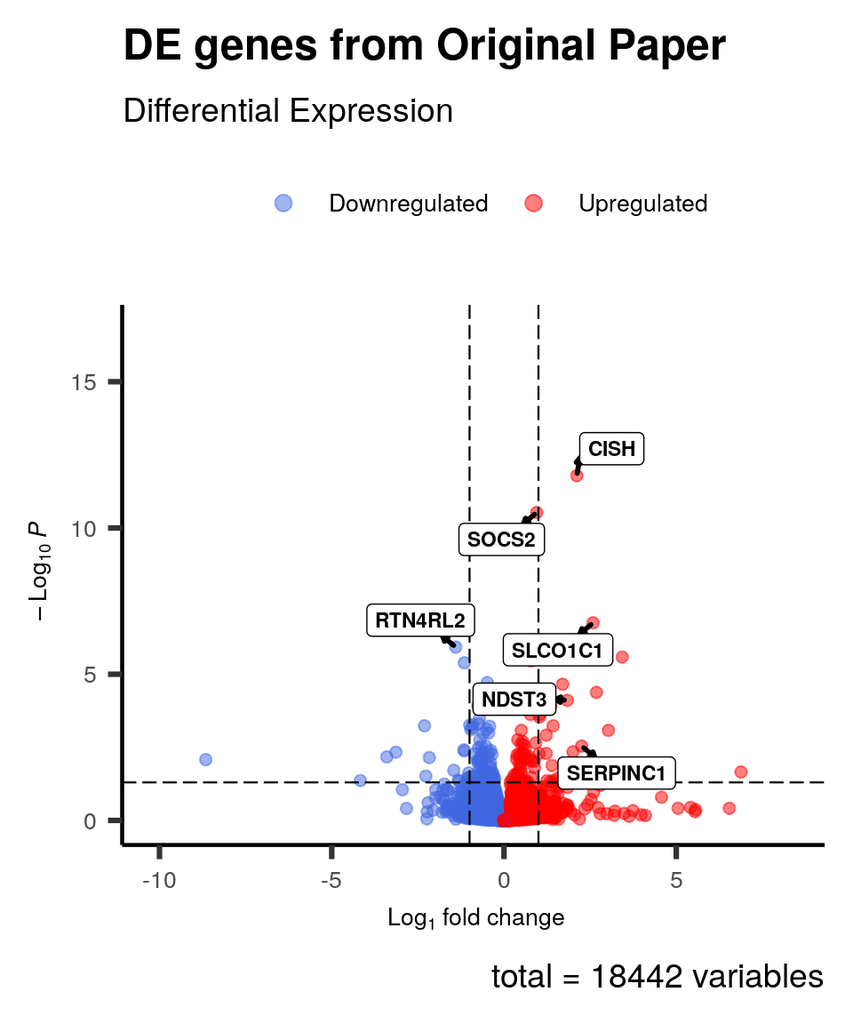

```r
# Genes from paper
keyvals <- ifelse(
  resdata_gene$log2FoldChange < 0, 'royalblue',
  ifelse(resdata_gene$log2FoldChange > 0, 'red',
         'black'))
keyvals[is.na(keyvals)] <- 'black'
names(keyvals)[keyvals == 'red'] <- 'Upregulated'
names(keyvals)[keyvals == 'black'] <- 'NA'
names(keyvals)[keyvals == 'royalblue'] <- 'Downregulated'

EnhancedVolcano(resdata_gene,
  lab = as.character(resdata_gene$external_gene_name),
  x = 'log2FoldChange',
  y = 'padj',
  selectLab = c('CISH', 'SLCO1C1', 'NDST3', 'SOCS2', 'SERPINC1', 'RTN4RL2'),
  xlab = bquote(~Log[1]~ 'fold change'),
  colCustom = keyvals,
  title = "DE genes from Original Paper",
  subtitle = "Differential Expression",
  FCcutoff = 1,
  pCutoff = 0.05,
  labSize = 3,
  axisLabSize = 10,
  labFace = 'bold',
  boxedLabels = TRUE,
  legendLabels=c('Not sig.','Log2FC','padj', 'padj & Log2FC'),
  legendPosition = 'top',
  legendLabSize = 10,
  legendIconSize = 3.0,
  drawConnectors = TRUE,
  widthConnectors = 1.0,
  colConnectors = 'black',
  gridlines.major = FALSE,
  gridlines.minor = FALSE)
```

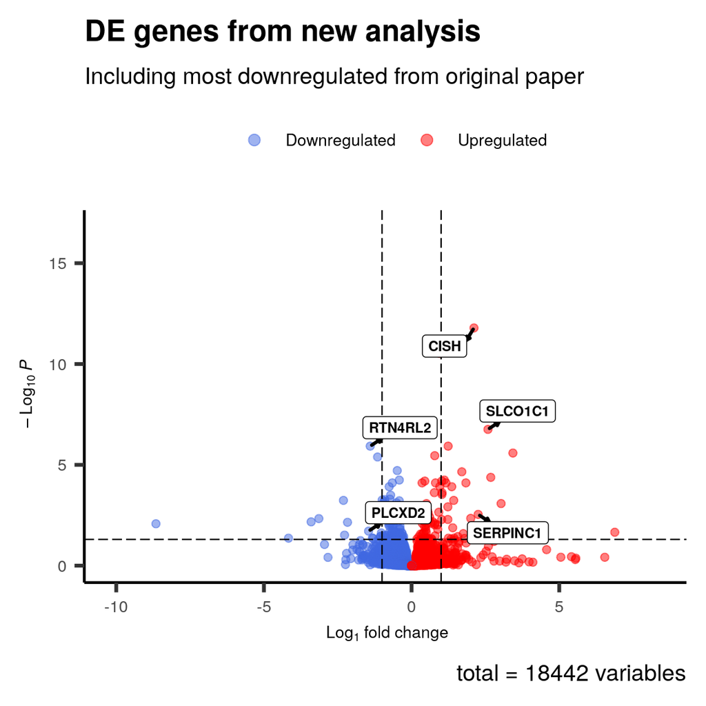

```r
# Genes from new analysis
keyvals <- ifelse(
  resdata_gene$log2FoldChange < 0, 'royalblue',
  ifelse(resdata_gene$log2FoldChange > 0, 'red',
         'black'))
keyvals[is.na(keyvals)] <- 'black'
names(keyvals)[keyvals == 'red'] <- 'Upregulated'
names(keyvals)[keyvals == 'black'] <- 'NA'
names(keyvals)[keyvals == 'royalblue'] <- 'Downregulated'

EnhancedVolcano(resdata_gene,
  lab = as.character(resdata_gene$external_gene_name),
  x = 'log2FoldChange',
  y = 'padj',
  selectLab = c('SLCO1C1', 'SERPINC1', 'CISH', 'PLCXD2', 'RTN4RL2'),
  xlab = bquote(~Log[1]~ 'fold change'),
  colCustom = keyvals,
  title = "DE genes from new analysis",
  subtitle = "Including most downregulated from original paper",
  FCcutoff = 1,
  pCutoff = 0.05,
  labSize = 3,
  axisLabSize = 10,
  labFace = 'bold',
  boxedLabels = TRUE,
  legendLabels=c('Not sig.','Log2FC','padj', 'padj & Log2FC'),
  legendPosition = 'top',
  legendLabSize = 10,
  legendIconSize = 3.0,
  drawConnectors = TRUE,
  widthConnectors = 1.0,
  colConnectors = 'black',
  gridlines.major = FALSE,
  gridlines.minor = FALSE)
```

Volcano plot was made from genes examined from pathway analysis

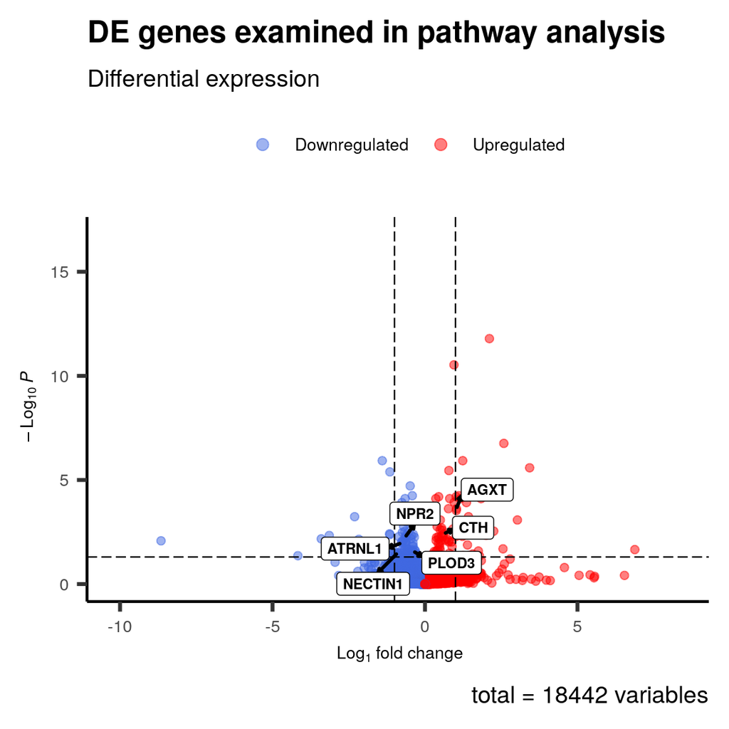

```r
# Genes from pathway analysis
keyvals <- ifelse(
  resdata_gene$log2FoldChange < 0, 'royalblue',
  ifelse(resdata_gene$log2FoldChange > 0, 'red',
         'black'))
keyvals[is.na(keyvals)] <- 'black'
names(keyvals)[keyvals == 'red'] <- 'Upregulated'
names(keyvals)[keyvals == 'black'] <- 'NA'
names(keyvals)[keyvals == 'royalblue'] <- 'Downregulated'

EnhancedVolcano(resdata_gene,
  lab = as.character(resdata_gene$external_gene_name),
  x = 'log2FoldChange',
  y = 'padj',
  selectLab = c('AGXT', 'CTH', 'NECTIN1', 'ATRNL1', 'PLOD3', 'NPR2'),
  xlab = bquote(~Log[1]~ 'fold change'),
  colCustom = keyvals,
  title = "DE genes examined in pathway analysis",
  subtitle = "Differential expression",
  FCcutoff = 1,
  pCutoff = 0.05,
  labSize = 3,
  axisLabSize = 10,
  labFace = 'bold',
  boxedLabels = TRUE,
  legendLabels=c('Not sig.','Log2FC','padj', 'padj & Log2FC'),
  legendPosition = 'top',
  legendLabSize = 10,
  legendIconSize = 3.0,
  drawConnectors = TRUE,
  widthConnectors = 1.0,
  colConnectors = 'black',
  gridlines.major = FALSE,
  gridlines.minor = FALSE)
```

## Heatmap

Heatmaps are useful by using color to depict changes between samples. In this case by season.

### Loading data

A csv file was made externally just containing the counts values for each sample, called `heatmap_input.csv`

```r
heatmap_normDEG <- read.csv("heatmap_input.csv", header = T, row.names = NULL)
head(heatmap_normDEG)
```

```
##    SRR7811754 SRR7811767  SRR7811766 SRR7811762 SRR7811764 SRR7811759
## 1  858.003269 329.633995  632.099887  385.40127 483.835954 2818.29622
## 2  574.166512 419.447315  549.457852  473.08006 543.333183 1004.18904
## 3   64.002406  20.064678   93.809877   45.28465  83.071602  347.49866
## 4 1216.973285 955.460854 1260.849421 1157.16730 762.238081 2008.37808
## 5  166.035227 358.297820  217.772929  321.81006 301.976500   74.78974
## 6    4.637856   5.732765    2.233569    2.89051   1.122589   45.60350
##   SRR7811758 SRR7811765 SRR7811757 SRR7811750
## 1  1761.1367 2029.35569 1871.78676 3020.44305
## 2   866.0177 1065.29564 1053.59299  955.40539
## 3   298.0385  740.22722  317.32230  198.29169
## 4  2125.4060 2557.82406 3739.42552 2291.37059
## 5   108.3776   78.94519  132.73613  129.19004
## 6    62.2168   33.43561   32.14703   10.01473
```

An annotation file was also made externally containing two columns, sample names and season designation.

```r
heatmap_meta <- read.csv("heatmap_anno.csv", header = T)
heatmap_meta
```

```
##        sample season
## 1  SRR7811754   fall
## 2  SRR7811767   fall
## 3  SRR7811766   fall
## 4  SRR7811762   fall
## 5  SRR7811764   fall
## 6  SRR7811759 spring
## 7  SRR7811758 spring
## 8  SRR7811765 spring
## 9  SRR7811757 spring
## 10 SRR7811750 spring
```

### Set up prior to using `pheatmap`

```r
# Assign the sample names to be the row names
rownames(heatmap_meta) <- heatmap_meta$sample
```

```r
# Re-level factors
heatmap_meta$season <- factor(heatmap_meta$season, levels = c("fall", "spring"))
```

```r
# Customized colors for heatmap
heatmap_colors <- colorRampPalette(c("blue", "white", "red"))(6)
```

```r
# Colors for denoting annotations
ann_colors <- list(genotype = c(spring = "#D11313", fall = "#6DB0F8"))
```

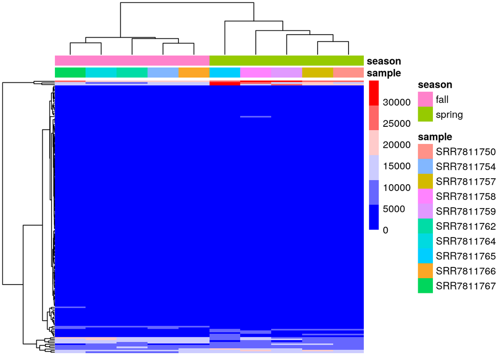

```r
# Plot heatmap
pheatmap(heatmap_normDEG,
         color = heatmap_colors,
         annotation_col = heatmap_meta,
         annotation_colors = ann_colors,
         show_colnames = F,
         show_rownames = F)
```

#### Z score

Z scores are measures of standard deviation used to plot the heatmap. How variable are samples from the mean

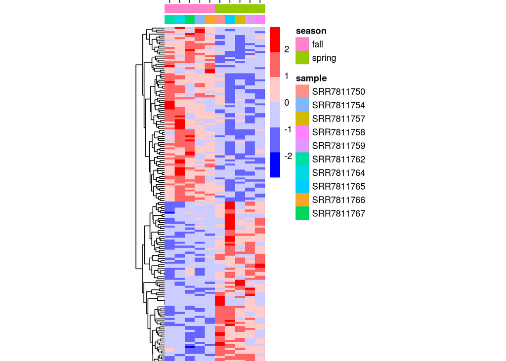

```r
# plot pheatmap
heatmap <- as.ggplot(pheatmap(heatmap_normDEG,
                              color = heatmap_colors,
                              cluster_rows = T,
                              annotation_col = heatmap_meta,
                              annotation_colors = ann_colors,
                              border_color="white",
                              cluster_cols = T,
                              show_colnames = F,
                              show_rownames = F,
                              scale="row",
                              treeheight_col = 10,
                              treeheight_row = 25,
                              cellwidth = 10,
                              cellheight = 2,
                              fontsize = 9,
                              annotation_names_col = F))
```

### Adding Annotation

```r
# Adding white space to add annotations to the top, right, bottom, and left margins
heatmap <- heatmap +
  theme(plot.margin = unit(c(1,0.5,0.5,0.5), "cm"))
```

[figure not shown]

```r
# Adding in annotations with cowplot
heatmap_figure <- ggdraw(heatmap) +
  draw_label("Bear Kidney Samples",
             x = 0.28,
             y = 0.97,
             size = 14,
             hjust = 0,
             vjust = 0) +
  draw_label("Fall",
             x = 0.25,
             y = 0.91,
             size = 12,
             hjust = -0.7,
             vjust = 0,
             fontface = "italic") +
  draw_label("Spring",
             x = 0.36,
             y = 0.91,
             size = 12,
             hjust = -0.5,
             vjust = 0,
             fontface = "italic") +
  draw_label("Up-regulated (79)",
             angle = 90,
             size = 10,
             x = 0.1,
             y = 0.5,
             hjust = -0.6,
             vjust = 0) +
  draw_label("Down-regulated (87)",
             angle = 90,
             size = 10,
             x = 0.1,
             y = 0.09,
             hjust = -0.7,
             vjust = 0)

heatmap_figure
```

## Pathway Analysis

#### Prepping the data

Need to use unfiltered matrix to convert to entrez id

```r
resdata <- read.csv("FallvsSpring_unfiltered_matrix.csv", header = T)
resdata <- resdata[, c(2:18)]
head(resdata)
```

```
##              Gene_id  baseMean log2FoldChange     lfcSE      stat       pvalue
## 1 ENSUAMG00000013871 1418.9993      2.1124384 0.2544389  8.302341 1.020800e-16
## 2 ENSUAMG00000025404  750.3986      0.9505259 0.1208698  7.864046 3.719209e-15
## 3 ENSUAMG00000016889  220.7612      2.5852960 0.3897986  6.632389 3.302964e-11
## 4 ENSUAMG00000004830 1807.5093      1.2374040 0.1966199  6.293382 3.106228e-10
## 5 ENSUAMG00000011450  188.9931     -1.4010826 0.2236332 -6.265092 3.726059e-10
## 6 ENSUAMG00000016642   20.0035      3.4316008 0.5614033  6.112541 9.805715e-10
##           padj  SRR7811754 SRR7811767  SRR7811766 SRR7811762 SRR7811764
## 1 1.623582e-12  858.003269 329.633995  632.099887  385.40127 483.835954
## 2 2.957701e-11  574.166512 419.447315  549.457852  473.08006 543.333183
## 3 1.751121e-07   64.002406  20.064678   93.809877   45.28465  83.071602
## 4 1.185259e-06 1216.973285 955.460854 1260.849421 1157.16731 762.238081
## 5 1.185259e-06  166.035227 358.297820  217.772929  321.81006 301.976500
## 6 2.599332e-06    4.637856   5.732765    2.233569    2.89051   1.122589
##   SRR7811759 SRR7811758 SRR7811765 SRR7811757 SRR7811750
## 1 2818.29622  1761.1367 2029.35569 1871.78676 3020.44305
## 2 1004.18904   866.0177 1065.29564 1053.59299  955.40539
## 3  347.49866   298.0385  740.22722  317.32230  198.29169
## 4 2008.37808  2125.4060 2557.82406 3739.42552 2291.37059
## 5   74.78974   108.3776   78.94519  132.73613  129.19004
## 6   45.60350    62.2168   33.43561   32.14703   10.01473
```

### BioMart id conversion

For this pathway analysis, mouse homologs will have to be used. Therefore, gene ids from bear must be obtained and then converted to mouse in order to be input for later packages.

American black bear selected first

```r
ensembl <- useEnsembl(biomart = "genes",
                      dataset = "uamericanus_gene_ensembl",
                      mirror="useast")
```

Make sure to obtain mouse orthologs for pathway analysis. either:  
- mmusculus_homolog_ensembl_gene

```r
biomart.output <- getBM(mart = ensembl, values = resdata$Gene_id,
                      filters = "ensembl_gene_id",
                      attributes = c("ensembl_gene_id",
                                     "mmusculus_homolog_ensembl_gene",
                                     "external_gene_name"))
```

Merge mouse annotations to resdata

```r
names(biomart.output)[1] <- "Gene_id"
#biomart.output
```

```r
resdata_gene <- dplyr::left_join(resdata, biomart.output,
                        by=c('Gene_id'='Gene_id'))
#resdata_gene
```

```r
write.csv(resdata_gene, "FallvsSpring_unfiltered_matrix_mouse.csv")
```

Input newly made file and remove rows without annotations.

```r
resdata_mouse <- read.csv("FallvsSpring_unfiltered_matrix_mouse2.csv", header = T)
resdata_mouse <- resdata_mouse[, c(2:18)]
head(resdata_mouse)
```

```
##   mmusculus_homolog_ensembl_gene  baseMean log2FoldChange     lfcSE      stat
## 1             ENSMUSG00000032578 1418.9993      2.1124384 0.2544389  8.302341
## 2             ENSMUSG00000020027  750.3986      0.9505259 0.1208698  7.864046
## 3             ENSMUSG00000030235  220.7612      2.5852960 0.3897986  6.632389
## 4                                1807.5093      1.2374040 0.1966199  6.293382
## 5             ENSMUSG00000050896  188.9931     -1.4010826 0.2236332 -6.265092
## 6             ENSMUSG00000060924   20.0035      3.4316008 0.5614033  6.112541
##     pvalue     padj  SRR7811754 SRR7811767  SRR7811766 SRR7811762 SRR7811764
## 1 1.02e-16 1.62e-12  858.003269 329.633995  632.099887  385.40127 483.835954
## 2 3.72e-15 2.96e-11  574.166512 419.447315  549.457852  473.08006 543.333183
## 3 3.30e-11 1.75e-07   64.002406  20.064678   93.809877   45.28465  83.071602
## 4 3.11e-10 1.19e-06 1216.973285 955.460854 1260.849421 1157.16730 762.238081
## 5 3.73e-10 1.19e-06  166.035227 358.297820  217.772929  321.81006 301.976500
## 6 9.81e-10 2.60e-06    4.637856   5.732765    2.233569    2.89051   1.122589
##   SRR7811759 SRR7811758 SRR7811765 SRR7811757 SRR7811750
## 1 2818.29622  1761.1367 2029.35569 1871.78676 3020.44305
## 2 1004.18904   866.0177 1065.29564 1053.59299  955.40539
## 3  347.49866   298.0385  740.22722  317.32230  198.29169
## 4 2008.37808  2125.4060 2557.82406 3739.42552 2291.37059
## 5   74.78974   108.3776   78.94519  132.73613  129.19004
## 6   45.60350    62.2168   33.43561   32.14703   10.01473
```

```r
# remove rows without ensembl gene ids
resdata_mouse <-
  resdata_mouse[!(is.na(resdata_mouse$mmusculus_homolog_ensembl_gene) | resdata_mouse$mmusculus_homolog_ensembl_gene==""), ]

head(resdata_mouse)
```

```
##   mmusculus_homolog_ensembl_gene  baseMean log2FoldChange     lfcSE      stat
## 1             ENSMUSG00000032578 1418.9993      2.1124384 0.2544389  8.302341
## 2             ENSMUSG00000020027  750.3986      0.9505259 0.1208698  7.864046
## 3             ENSMUSG00000030235  220.7612      2.5852960 0.3897986  6.632389
## 5             ENSMUSG00000050896  188.9931     -1.4010826 0.2236332 -6.265092
## 6             ENSMUSG00000060924   20.0035      3.4316008 0.5614033  6.112541
## 7             ENSMUSG00000044715  941.7348      0.7836418 0.1297604  6.039146
##     pvalue     padj SRR7811754 SRR7811767 SRR7811766 SRR7811762 SRR7811764
## 1 1.02e-16 1.62e-12 858.003269 329.633995 632.099887  385.40127 483.835954
## 2 3.72e-15 2.96e-11 574.166512 419.447315 549.457852  473.08006 543.333183
## 3 3.30e-11 1.75e-07  64.002406  20.064678  93.809877   45.28465  83.071602
## 5 3.73e-10 1.19e-06 166.035227 358.297820 217.772929  321.81006 301.976500
## 6 9.81e-10 2.60e-06   4.637856   5.732765   2.233569    2.89051   1.122589
## 7 1.55e-09 3.52e-06 790.290578 683.154511 623.165613  753.45948 601.707822
##   SRR7811759 SRR7811758 SRR7811765 SRR7811757 SRR7811750
## 1 2818.29622  1761.1367 2029.35569 1871.78676 3020.44305
## 2 1004.18904   866.0177 1065.29564 1053.59299  955.40539
## 3  347.49866   298.0385  740.22722  317.32230  198.29169
## 5   74.78974   108.3776   78.94519  132.73613  129.19004
## 6   45.60350    62.2168   33.43561   32.14703   10.01473
## 7 1219.43755   932.2484 1178.60520 1356.39728 1278.88122
```

Use BioMart for the mouse dataset

```r
ensembl <- useEnsembl(biomart = "genes",
                      dataset = "mmusculus_gene_ensembl",
                      mirror="useast")
```

Obtain entrezgene ids from mouse ensembl ids

```r
biomart.output <- getBM(mart = ensembl, values = resdata_mouse$mmusculus_homolog_ensembl_gene,
                      filters = "ensembl_gene_id",
                      attributes = c("ensembl_gene_id",
                                     "entrezgene_id",
                                     "external_gene_name"))
head(biomart.output)
```

```
##      ensembl_gene_id entrezgene_id external_gene_name
## 1 ENSMUSG00000000056         67608               Narf
## 2 ENSMUSG00000000058         12390               Cav2
## 3 ENSMUSG00000000088         12858              Cox5a
## 4 ENSMUSG00000000148        231841              Brat1
## 5 ENSMUSG00000000154         18400           Slc22a18
## 6 ENSMUSG00000000159         72058              Igsf5
```

```r
#write.csv(biomart.output, "mouse_gene_names.csv)
# will need this output to identify mouse genes from pathway analysis to compare back to bear
```

Merge entrezgene_id with resdata_mouse

```r
names(biomart.output)[1] <- "mmusculus_homolog_ensembl_gene"
#biomart.output
```

```r
resdata_mouse <- dplyr::left_join(resdata_mouse, biomart.output,
                        by=c('mmusculus_homolog_ensembl_gene'= 'mmusculus_homolog_ensembl_gene'))
#resdata_mouse

write.csv(resdata_mouse, "resdata_mouse.csv")
```

### Create Gene lists

A list of background and significant genes are needed to perform over-representation analysis.

Can make two data frames that show up and down-regulated genes based on log2FC and padj value.

```r
UpGenes <-
  resdata_mouse %>%
  filter(log2FoldChange > 0 & padj < 0.05) %>%
  as.data.frame()


DownGenes <-
  resdata_mouse %>%
  filter(log2FoldChange < 0 & padj < 0.05) %>%
  as.data.frame()
```

### Prep background gene set

```r
# we want the log2 fold change
original_gene_list <- resdata_mouse$log2FoldChange
head(original_gene_list)
```

```
## [1]  2.1124384  0.9505259  2.5852960 -1.4010826  3.4316008  0.7836418
```

```r
# name the vector
names(original_gene_list) <- resdata_mouse$mmusculus_homolog_ensembl_gene
head(original_gene_list)
```

```
## ENSMUSG00000032578 ENSMUSG00000020027 ENSMUSG00000030235 ENSMUSG00000050896
##          2.1124384          0.9505259          2.5852960         -1.4010826
## ENSMUSG00000060924 ENSMUSG00000044715
##          3.4316008          0.7836418
```

```r
# omit any NA values
gene_list <- na.omit(original_gene_list)
head(gene_list)
```

```
## ENSMUSG00000032578 ENSMUSG00000020027 ENSMUSG00000030235 ENSMUSG00000050896
##          2.1124384          0.9505259          2.5852960         -1.4010826
## ENSMUSG00000060924 ENSMUSG00000044715
##          3.4316008          0.7836418
```

```r
# sort the list in decreasing order (will be required so good to do this now)
gene_list = sort(gene_list, decreasing = TRUE)
head(gene_list)
```

```
## ENSMUSG00000105906 ENSMUSG00000105906 ENSMUSG00000105547 ENSMUSG00000105547
##           6.880774           6.880774           6.880774           6.880774
## ENSMUSG00000106039 ENSMUSG00000106039
##           6.880774           6.880774
```

#### Prep significant gene set

```r
# Extract significant results (padj < 0.05) using subset()
sig_genes_df = subset(resdata_mouse, padj < 0.05)

# From significant results, we want to filter on padj value
genes <- sig_genes_df$padj

# Name the vector i.e. add mouse ensembl id
names(genes) <- sig_genes_df$mmusculus_homolog_ensembl_gene

# omit NA values
genes <- na.omit(genes)

# set genes as new object
genes <- names(genes)
head(genes)
```

```
## [1] "ENSMUSG00000032578" "ENSMUSG00000020027" "ENSMUSG00000030235"
## [4] "ENSMUSG00000050896" "ENSMUSG00000060924" "ENSMUSG00000044715"
```

### Perform GO Enrichment Analysis

These analyses aid in identifying which pathways the genes in the dataset are involved in.

#### Cellular Component

Use `keytypes()` to select correct input, this is `ENSEMBL`

```r
keytypes(org.Mm.eg.db)
```

```
##  [1] "ACCNUM"       "ALIAS"        "ENSEMBL"      "ENSEMBLPROT"  "ENSEMBLTRANS"
##  [6] "ENTREZID"     "ENZYME"       "EVIDENCE"     "EVIDENCEALL"  "GENENAME"
## [11] "GENETYPE"     "GO"           "GOALL"        "IPI"          "MGI"
## [16] "ONTOLOGY"     "ONTOLOGYALL"  "PATH"         "PFAM"         "PMID"
## [21] "PROSITE"      "REFSEQ"       "SYMBOL"       "UNIPROT"
```

```r
go_enrich <- enrichGO(gene = genes,
                      universe = names(gene_list),
                      OrgDb = org.Mm.eg.db,
                      keyType = 'ENSEMBL',
                      readable = T,
                      ont = "CC",
                      pvalueCutoff = 0.05,
                      qvalueCutoff = 0.05)
```

```r
## Output results from GO analysis to a table
cluster_summary <- data.frame(go_enrich)

write.csv(cluster_summary, "clusterProfiler_bear_CC.csv")

head(cluster_summary)
```

```
##                    ID                         Description GeneRatio  BgRatio
## GO:0042571 GO:0042571 immunoglobulin complex, circulating     4/122 32/14381
## GO:0019814 GO:0019814              immunoglobulin complex     4/122 38/14381
## GO:0043083 GO:0043083                      synaptic cleft     3/122 17/14381
##                  pvalue  p.adjust     qvalue                  geneID Count
## GO:0042571 0.0001475198 0.0295846 0.02801449 Iglc1/Iglc3/Iglc4/Iglc2     4
## GO:0019814 0.0002911570 0.0295846 0.02801449 Iglc1/Iglc3/Iglc4/Iglc2     4
## GO:0043083 0.0003713548 0.0295846 0.02801449       C1ql1/Gria3/Lama5     3
```

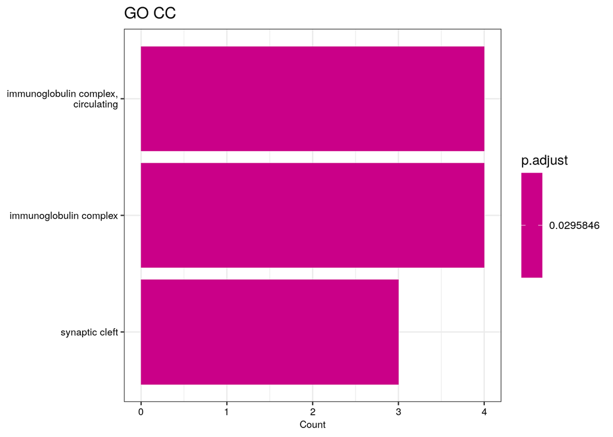

```r
barplot <- barplot(go_enrich, showCategory = 10,
                   title = "GO CC",
                   font.size = 8)

barplot
```

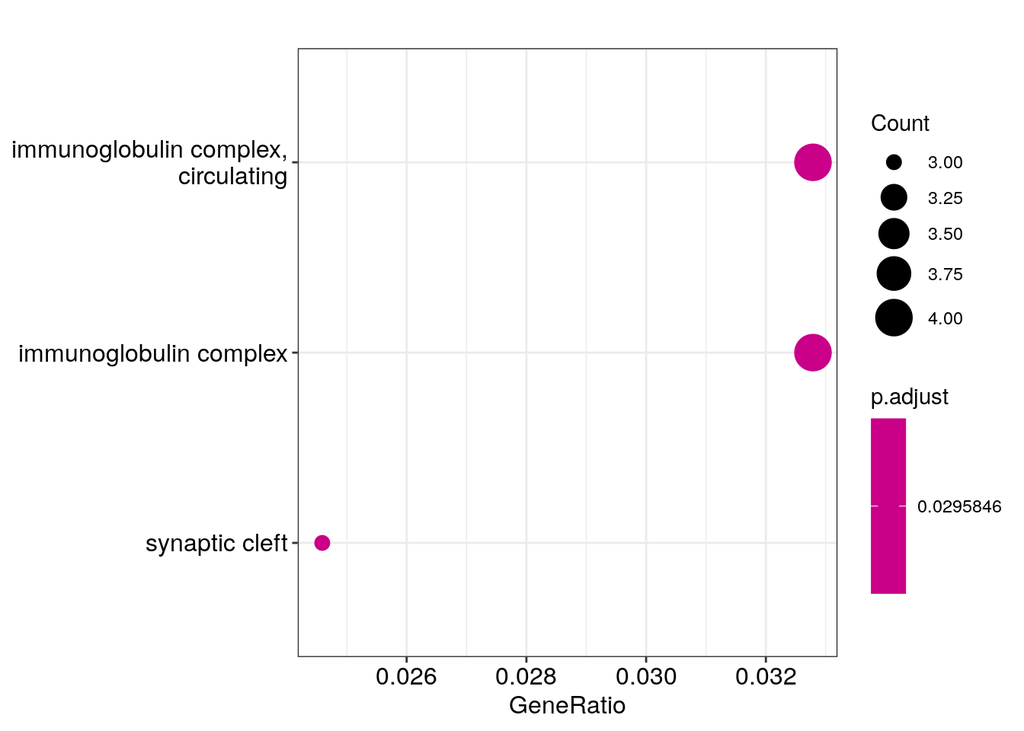

```r
dot <- dotplot(go_enrich)
dot
```

#### Biological Process

Use `keytypes()` to select correct input, this is `ENSEMBL`

```r
keytypes(org.Mm.eg.db)
```

```
##  [1] "ACCNUM"       "ALIAS"        "ENSEMBL"      "ENSEMBLPROT"  "ENSEMBLTRANS"
##  [6] "ENTREZID"     "ENZYME"       "EVIDENCE"     "EVIDENCEALL"  "GENENAME"
## [11] "GENETYPE"     "GO"           "GOALL"        "IPI"          "MGI"
## [16] "ONTOLOGY"     "ONTOLOGYALL"  "PATH"         "PFAM"         "PMID"
## [21] "PROSITE"      "REFSEQ"       "SYMBOL"       "UNIPROT"
```

```r
go_enrich <- enrichGO(gene = genes,
                      universe = names(gene_list),
                      OrgDb = org.Mm.eg.db,
                      keyType = 'ENSEMBL',
                      readable = T,
                      ont = "BP",
                      pvalueCutoff = 0.05,
                      qvalueCutoff = 0.05)
```

```r
## Output results from GO analysis to a table
cluster_summary <- data.frame(go_enrich)

write.csv(cluster_summary, "clusterProfiler_bear_BP.csv")

head(cluster_summary)
```

```
##                    ID                        Description GeneRatio   BgRatio
## GO:1901605 GO:1901605 alpha-amino acid metabolic process     9/123 172/14279
##                  pvalue   p.adjust     qvalue
## GO:1901605 1.758679e-05 0.03774124 0.03661754
##                                                       geneID Count
## GO:1901605 Agxt/Cth/Aspg/Tst/Acmsd/Plod3/Glud1/Aldh6a1/Nr1h4     9
```

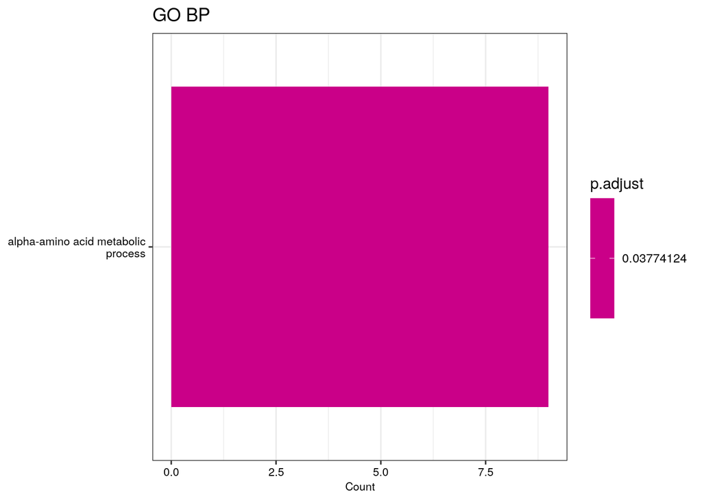

```r
barplot <- barplot(go_enrich, showCategory = 10,
                   title = "GO BP",
                   font.size = 8)

barplot
```

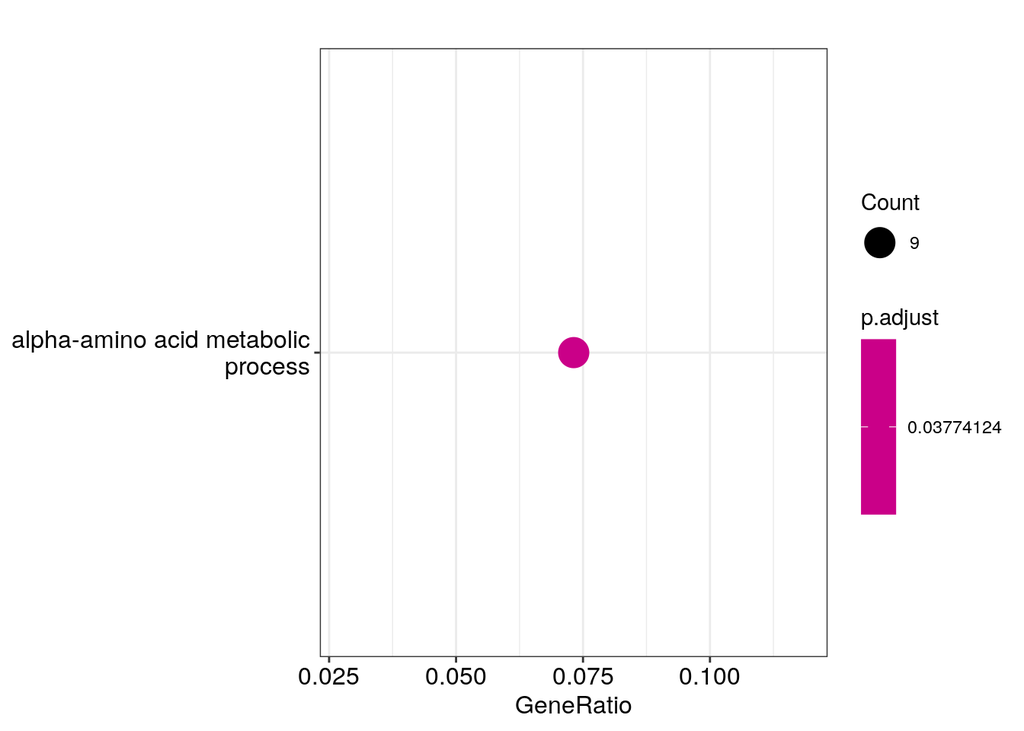

```r
dot <- dotplot(go_enrich)
dot
```

### Molecular Function

Use `keytypes()` to select correct input, this is `ENSEMBL`

```r
keytypes(org.Mm.eg.db)
```

```
##  [1] "ACCNUM"       "ALIAS"        "ENSEMBL"      "ENSEMBLPROT"  "ENSEMBLTRANS"
##  [6] "ENTREZID"     "ENZYME"       "EVIDENCE"     "EVIDENCEALL"  "GENENAME"
## [11] "GENETYPE"     "GO"           "GOALL"        "IPI"          "MGI"
## [16] "ONTOLOGY"     "ONTOLOGYALL"  "PATH"         "PFAM"         "PMID"
## [21] "PROSITE"      "REFSEQ"       "SYMBOL"       "UNIPROT"
```

```r
go_enrich <- enrichGO(gene = genes,
                      universe = names(gene_list),
                      OrgDb = org.Mm.eg.db,
                      keyType = 'ENSEMBL',
                      readable = T,
                      ont = "MF",
                      pvalueCutoff = 0.05,
                      qvalueCutoff = 0.05)
```

```r
## Output results from GO analysis to a table
cluster_summary <- data.frame(go_enrich)

write.csv(cluster_summary, "clusterProfiler_bear_MF.csv")

head(cluster_summary)
```

```
##                    ID          Description GeneRatio   BgRatio       pvalue
## GO:0043177 GO:0043177 organic acid binding     7/125 127/14127 0.0001331837
##              p.adjust     qvalue                                     geneID
## GO:0043177 0.04927798 0.04640401 Slc46a1/Agxt/Gchfr/Plod3/Sesn2/Glud1/Nr1h4
##            Count
## GO:0043177     7
```

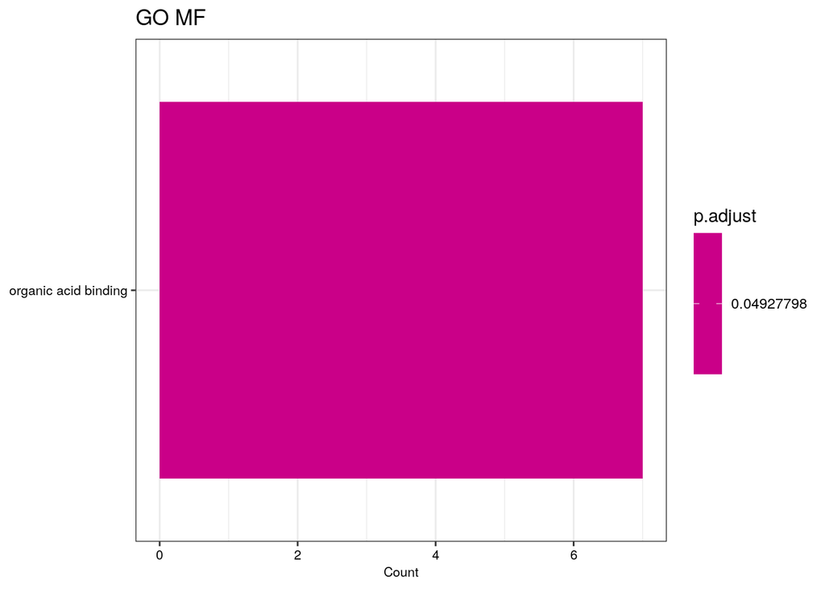

```r
barplot <- barplot(go_enrich, showCategory = 10,
                   title = "GO MF",
                   font.size = 8)

barplot
```

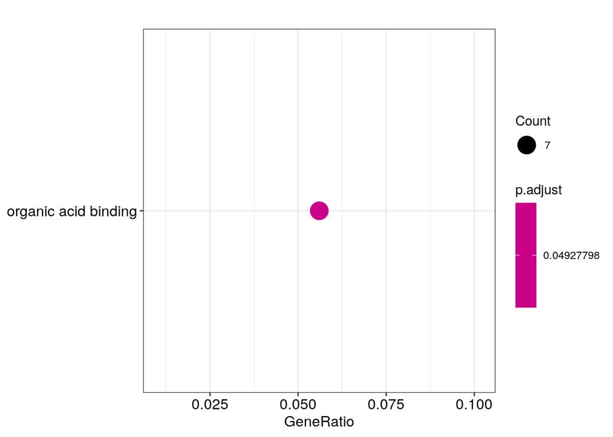

```r
dot <- dotplot(go_enrich)
dot
```

```r
# using the biomart.outputs create the genelists from up
UpGenes <- UpGenes %>%
  dplyr::select(external_gene_name) %>%
  dplyr::rename("gene" = "external_gene_name")
UpGenes <- mutate_all(UpGenes, .funs=toupper) #makes it easy to apply the same transformation on multiple variables

# using the biomart.outputs create the genelists from down
DownGenes <- DownGenes %>%
  dplyr::select(external_gene_name) %>%
  dplyr::rename("gene" = "external_gene_name")
DownGenes <- mutate_all(DownGenes, .funs=toupper) #makes it easy to apply the same transformation on multiple variables

#load geneset
KEGG <- msigdb_gsets(species="Homo sapiens", category="C2", subcategory="CP:KEGG")
PID <- msigdb_gsets(species="Homo sapiens", category="C2", subcategory="CP:PID")
GOBP<- msigdb_gsets(species = "Homo sapiens", "C5", "GO:BP")
react<- msigdb_gsets("Homo sapiens", "C2", "CP:REACTOME")
HALL<- msigdb_gsets("Homo sapiens", "H")

#load gene list - this gene list is ALL DE genes - not separated by UP or DOWN
x_up <- UpGenes[which(UpGenes$gene !=""),1]
x_down <- DownGenes[which(DownGenes$gene !=""),1]
```

### Pathway Analysis for Up-regulated genes

```r
#KEGG
hyp_1 <- hypeR(x_up, KEGG, test="hypergeometric", background=50000, pval = 0.05, plotting=TRUE)
print(hyp_1)
```

```
## (hyp)
##
##   data:
##                                            label    pval   fdr signature
##                         KEGG_NITROGEN_METABOLISM 0.00036 0.044        61
##     KEGG_GLYCINE_SERINE_AND_THREONINE_METABOLISM 0.00067 0.044        61
##  KEGG_ALANINE_ASPARTATE_AND_GLUTAMATE_METABOLISM 0.00071 0.044        61
##                                  KEGG_PEROXISOME 0.00410 0.190        61
##                  KEGG_JAK_STAT_SIGNALING_PATHWAY 0.01600 0.580        61
##     KEGG_PROXIMAL_TUBULE_BICARBONATE_RECLAMATION 0.02800 0.630        61
##  geneset overlap background       hits
##       23       2      50000  CTH,GLUD1
##       31       2      50000   AGXT,CTH
##       32       2      50000 AGXT,GLUD1
##       78       2      50000 ACSL5,AGXT
##      155       2      50000 CISH,SOCS2
##       23       1      50000      GLUD1
##
##   plots: 14 Figures
##
##   args: signature
##         genesets
##         test
##         background
##         power
##         absolute
##         pval
##         fdr
##         plotting
##         quiet
```

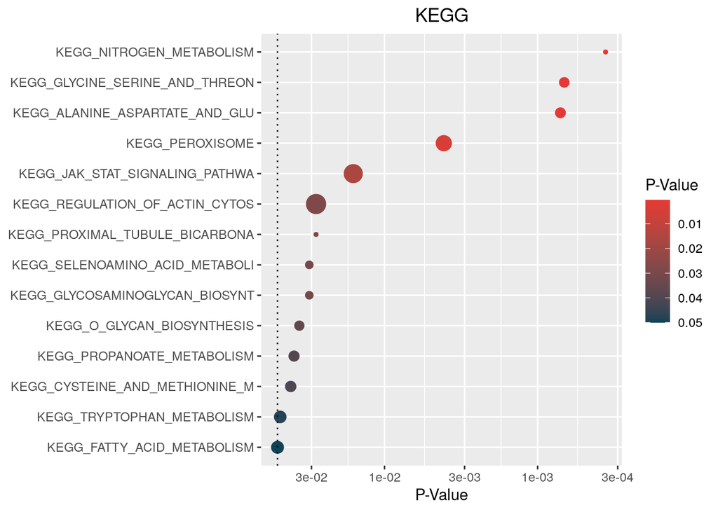

```r
hyp_dots(hyp_1, title = "KEGG", abrv = 30, val = "pval")
```

```r
#PID
hyp_1_pid <- hypeR(x_up, PID, test="hypergeometric", background=50000, pval=0.05, plotting=TRUE)
print(hyp_1_pid)
```

```
## (hyp)
##
##   data:
##                             label   pval  fdr signature geneset overlap
##                  PID_IL2_1PATHWAY 0.0021 0.41        61      55       2
##                   PID_IL5_PATHWAY 0.0170 0.62        61      14       1
##              PID_S1P_S1P4_PATHWAY 0.0170 0.62        61      14       1
##         PID_THROMBIN_PAR4_PATHWAY 0.0180 0.62        61      15       1
##              PID_S1P_META_PATHWAY 0.0250 0.62        61      21       1
##  PID_PRL_SIGNALING_EVENTS_PATHWAY 0.0280 0.62        61      23       1
##  background       hits
##       50000 CISH,SOCS2
##       50000       CISH
##       50000      GNA13
##       50000      GNA13
##       50000      GNA13
##       50000     PTP4A1
##
##   plots: 13 Figures
##
##   args: signature
##         genesets
##         test
##         background
##         power
##         absolute
##         pval
##         fdr
##         plotting
##         quiet
```

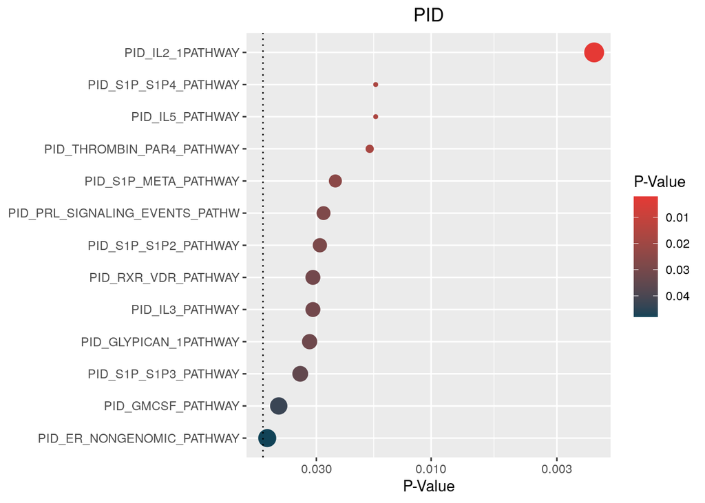

```r
hyp_dots(hyp_1_pid, title = "PID", abrv = 30, val = "pval")
```

```r
# GOBP
hyp_1_G <- hypeR(x_up, GOBP, test="hypergeometric", background=50000, fdr=0.05, plotting=TRUE)
print(hyp_1_G)
```

```
## (hyp)
##
##   data:
##                                              label    pval     fdr signature
##            GOBP_ALPHA_AMINO_ACID_METABOLIC_PROCESS 6.1e-09 4.7e-05        61
##         GOBP_CELLULAR_AMINO_ACID_METABOLIC_PROCESS 6.2e-08 2.4e-04        61
##  GOBP_ORGANONITROGEN_COMPOUND_BIOSYNTHETIC_PROCESS 1.1e-07 2.9e-04        61
##                GOBP_ORGANIC_ACID_METABOLIC_PROCESS 2.5e-07 4.8e-04        61
##                    GOBP_CYSTEINE_METABOLIC_PROCESS 3.8e-07 5.8e-04        61
##                       GOBP_REGULATION_OF_TRANSPORT 1.1e-06 1.5e-03        61
##  geneset overlap background
##      204       7      50000
##      286       7      50000
##     1703      13      50000
##      964      10      50000
##       12       3      50000
##     1749      12      50000
##                                                                              hits
##                                            ACMSD,AGXT,ALDH6A1,CTH,GLUD1,NR1H4,TST
##                                            ACMSD,AGXT,ALDH6A1,CTH,GLUD1,NR1H4,TST
##  ACMSD,ACSL5,AGXT,CTH,EIF3L,EIF4A1,GALNT5,GLUD1,NDST3,NUS1,RAB38,SELENOK,SLC25A38
##                         ACMSD,ACSL5,AGXT,ALDH6A1,CTH,GLUD1,LYPLA1,NR1H4,NUPR1,TST
##                                                                      AGXT,CTH,TST
##          ACSL5,CLIC5,DNAJC6,GLUD1,LYPLA1,MCU,NKAIN1,NR1H4,NUS1,SELENOK,SRI,STXBP1
##
##   plots: 87 Figures
##
##   args: signature
##         genesets
##         test
##         background
##         power
##         absolute
##         pval
##         fdr
##         plotting
##         quiet
```